# Lab-06

Ecosystem Science and Sustainability 330

Author

Tayler Kordiak

## Question One

```r
library(tidyverse)
library(tidymodels)
library(powerjoin)
library(glue)
library(vip)
```

```r
library(baguette)
```

```r
root <- 'https://gdex.ucar.edu/dataset/camels/file'
download.file('https://gdex.ucar.edu/dataset/camels/file/camels_attributes_v2.0.pdf',
              'data/camels_attributes_v2.0.pdf')
```

```r
types <- c("clim", "geol", "soil", "topo", "vege", "hydro")
remote_files <- glue('{root}/camels_{types}.txt')
local_files <- glue('data/camels_{types}.txt')
```

```r
walk2(remote_files, local_files, download.file, quite = TRUE)
```

```r
camels <- map(local_files, read_delim, show_col_types = FALSE)
```

#the zero_q_freq from the camels attribute means the frequency of days with stream flow equals zero mm per day that is in units of percentages and is from the N15 - USGS data set.

```r
camels <- power_full_join(camels ,by = "gauge_id")
```

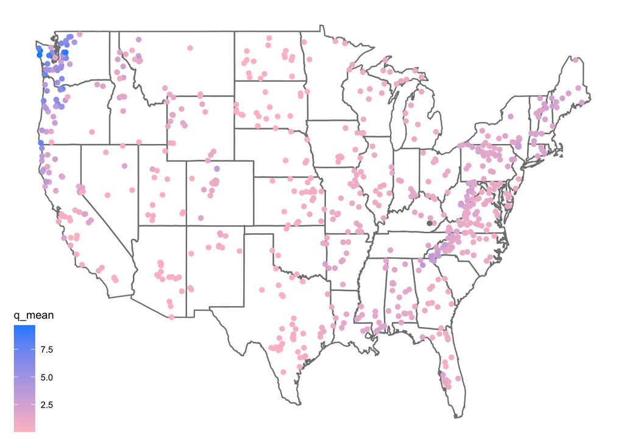

```r
library(ggplot2)
ggplot(data = camels, aes(x = gauge_lon, y = gauge_lat)) +
  borders("state", colour = "gray50") +
  geom_point(aes(color = q_mean)) +
  scale_color_gradient(low = "pink", high = "dodgerblue") +
  ggthemes::theme_map()
```

## Question Two

```r
camels |>
  select(aridity, p_mean, q_mean) |>
  drop_na() |>
  cor()
```

```
           aridity     p_mean     q_mean
aridity  1.0000000 -0.7550090 -0.5817771
p_mean  -0.7550090  1.0000000  0.8865757
q_mean  -0.5817771  0.8865757  1.0000000
```

```r
print(camels)
```

```
# A tibble: 671 × 58
   gauge_id p_mean pet_mean p_seasonality frac_snow aridity high_prec_freq
   <chr>     <dbl>    <dbl>         <dbl>     <dbl>   <dbl>          <dbl>
 1 01013500   3.13     1.97        0.188      0.313   0.631           13.0
 2 01022500   3.61     2.12       -0.115      0.245   0.587           20.6
 3 01030500   3.27     2.04        0.0474     0.277   0.624           17.2
 4 01031500   3.52     2.07        0.104      0.292   0.588           18.9
 5 01047000   3.32     2.09        0.148      0.280   0.629           20.1
 6 01052500   3.73     2.10        0.152      0.353   0.562           13.5
 7 01054200   4.07     2.13        0.105      0.300   0.523           17.5
 8 01055000   3.49     2.09        0.167      0.306   0.599           19.2
 9 01057000   3.57     2.13        0.0791     0.251   0.597           20.4
10 01073000   3.50     2.21        0.0304     0.175   0.630           20.8
# ℹ 661 more rows
# ℹ 51 more variables: high_prec_dur <dbl>, high_prec_timing <chr>,
#   low_prec_freq <dbl>, low_prec_dur <dbl>, low_prec_timing <chr>,
#   geol_1st_class <chr>, glim_1st_class_frac <dbl>, geol_2nd_class <chr>,
#   glim_2nd_class_frac <dbl>, carbonate_rocks_frac <dbl>, geol_porostiy <dbl>,
#   geol_permeability <dbl>, soil_depth_pelletier <dbl>,
#   soil_depth_statsgo <dbl>, soil_porosity <dbl>, soil_conductivity <dbl>, …
```

#scatterplot

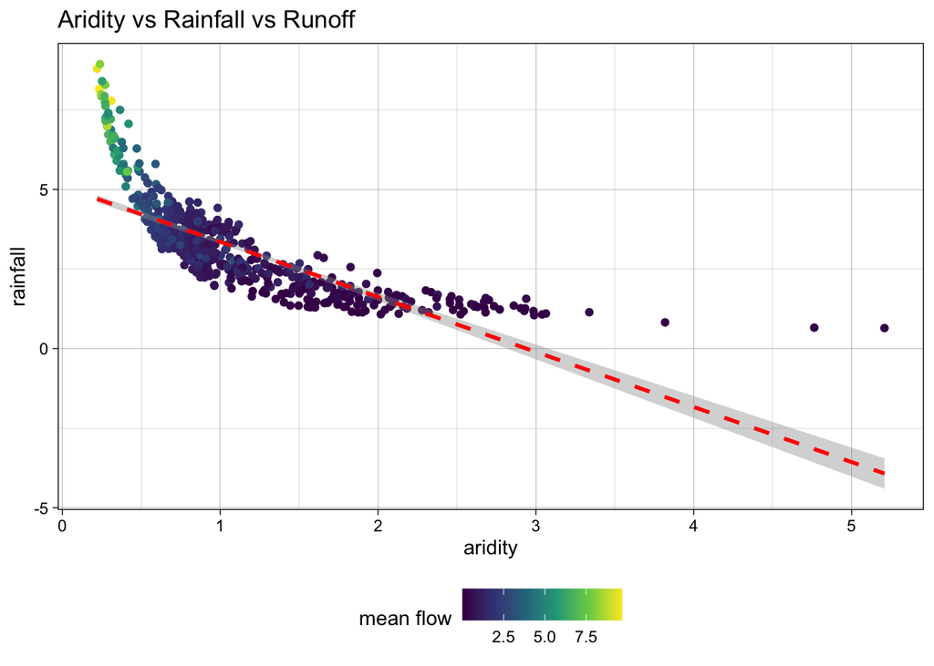

```r
ggplot(camels, aes(x = aridity, y = p_mean)) +
  geom_point(aes(color = q_mean)) +
  geom_smooth(method = "lm", color = "red", linetype = 2) +
              scale_color_viridis_c() +
              theme_linedraw() + theme(legend.position = "bottom") +
  labs(title = "Aridity vs Rainfall vs Runoff",
       x = "aridity",
       y = "rainfall",
       color = "mean flow")
```

#transformation

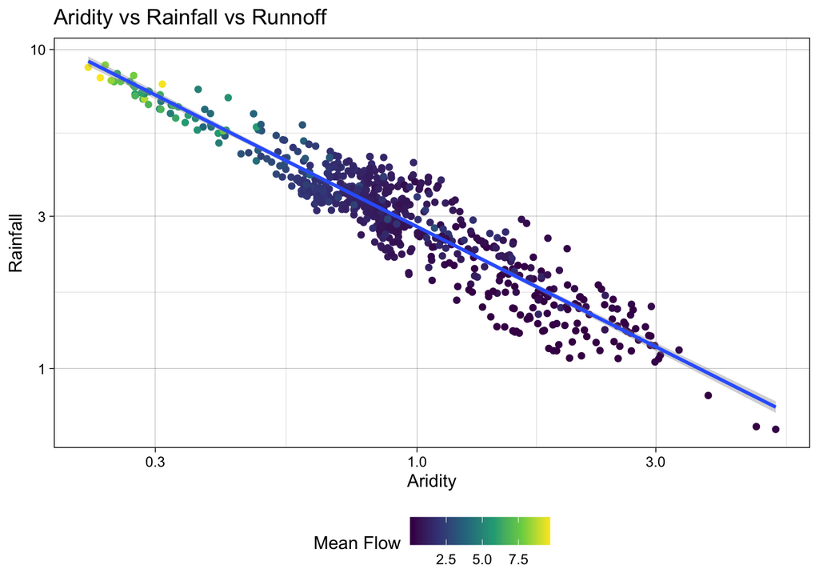

```r
ggplot(camels, aes(x = aridity, y = p_mean)) +
  geom_point(aes(color = q_mean)) +
  geom_smooth(method = "lm") +
  scale_color_viridis_c() +
  # Apply log transformations to the x and y axes
  scale_x_log10() +
  scale_y_log10() +
  theme_linedraw() +
  theme(legend.position = "bottom") +
  labs(title = "Aridity vs Rainfall vs Runnoff",
       x = "Aridity",
       y = "Rainfall",
       color = "Mean Flow")
```

#another transformation

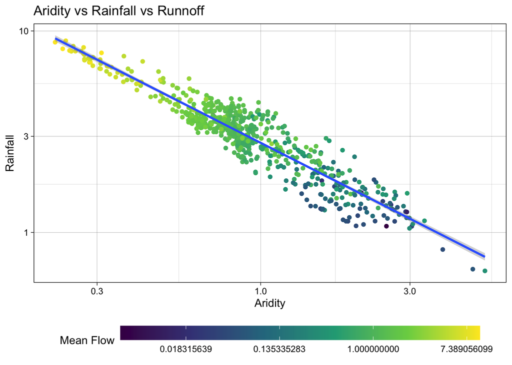

```r
ggplot(camels, aes(x = aridity, y = p_mean)) +
  geom_point(aes(color = q_mean)) +
  geom_smooth(method = "lm") +
  # Apply a log transformation to the color scale
  scale_color_viridis_c(trans = "log") +
  scale_x_log10() +
  scale_y_log10() +
  theme_linedraw() +
  theme(legend.position = "bottom",
        # Expand the legend width ...
        legend.key.width = unit(2.5, "cm"),
        legend.key.height = unit(.5, "cm")) +
  labs(title = "Aridity vs Rainfall vs Runnoff",
       x = "Aridity",
       y = "Rainfall",
       color = "Mean Flow")
```

#model building

```r
set.seed(123)
camels <- camels |>
  mutate(logQmean = log(q_mean))

camels_split <- initial_split(camels, prop = 0.8)
camels_train <- training(camels_split)
camels_test  <- testing(camels_split)

camels_cv <- vfold_cv(camels_train, v = 10)
```

#preprocessor

```r
rec <-  recipe(logQmean ~ aridity + p_mean, data = camels_train) %>%
  step_log(all_predictors()) %>%
  step_interact(terms = ~ aridity:p_mean) |>
  step_naomit(all_predictors(), all_outcomes())
```

#Naive approach

```r
baked_data <- prep(rec, camels_train) |>
  bake(new_data = NULL)

lm_base <- lm(logQmean ~ aridity * p_mean, data = baked_data)
summary(lm_base)
```

```
Call:
lm(formula = logQmean ~ aridity * p_mean, data = baked_data)

Residuals:
     Min       1Q   Median       3Q      Max
-2.91162 -0.21601 -0.00716  0.21230  2.85706

Coefficients:
               Estimate Std. Error t value Pr(>|t|)
(Intercept)    -1.77586    0.16365 -10.852  < 2e-16 ***
aridity        -0.88397    0.16145  -5.475 6.75e-08 ***
p_mean          1.48438    0.15511   9.570  < 2e-16 ***
aridity:p_mean  0.10484    0.07198   1.457    0.146
---
Signif. codes:  0 '***' 0.001 '**' 0.01 '*' 0.05 '.' 0.1 ' ' 1

Residual standard error: 0.5696 on 531 degrees of freedom
Multiple R-squared:  0.7697,    Adjusted R-squared:  0.7684
F-statistic: 591.6 on 3 and 531 DF,  p-value: < 2.2e-16
```

```r
summary(lm(logQmean ~ aridity + p_mean + aridity_x_p_mean, data = baked_data))
```

```
Call:
lm(formula = logQmean ~ aridity + p_mean + aridity_x_p_mean,
    data = baked_data)

Residuals:
     Min       1Q   Median       3Q      Max
-2.91162 -0.21601 -0.00716  0.21230  2.85706

Coefficients:
                 Estimate Std. Error t value Pr(>|t|)
(Intercept)      -1.77586    0.16365 -10.852  < 2e-16 ***
aridity          -0.88397    0.16145  -5.475 6.75e-08 ***
p_mean            1.48438    0.15511   9.570  < 2e-16 ***
aridity_x_p_mean  0.10484    0.07198   1.457    0.146
---
Signif. codes:  0 '***' 0.001 '**' 0.01 '*' 0.05 '.' 0.1 ' ' 1

Residual standard error: 0.5696 on 531 degrees of freedom
Multiple R-squared:  0.7697,    Adjusted R-squared:  0.7684
F-statistic: 591.6 on 3 and 531 DF,  p-value: < 2.2e-16
```

# correct version of validating the data

```r
test_data <-  bake(prep(rec), new_data = camels_test)
test_data$lm_pred <- predict(lm_base, newdata = test_data)
```

```r
metrics(test_data, truth = logQmean, estimate = lm_pred)
```

```
# A tibble: 3 × 3
  .metric .estimator .estimate
  <chr>   <chr>          <dbl>
1 rmse    standard       0.583
2 rsq     standard       0.742
3 mae     standard       0.390
```

#plot

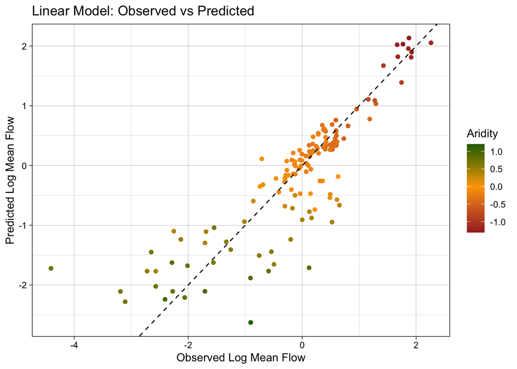

```r
ggplot(test_data, aes(x = logQmean, y = lm_pred, colour = aridity)) +
  # Apply a gradient color scale
  scale_color_gradient2(low = "brown", mid = "orange", high = "darkgreen") +
  geom_point() +
  geom_abline(linetype = 2) +
  theme_linedraw() +
  labs(title = "Linear Model: Observed vs Predicted",
       x = "Observed Log Mean Flow",
       y = "Predicted Log Mean Flow",
       color = "Aridity")
```

#better -> workflow

```r
#define model
lm_model <- linear_reg() %>%
  # define the engine
  set_engine("lm") %>%
  # define the mode
  set_mode("regression")

# Instantiate a workflow ...
lm_wf <- workflow() %>%
  # Add the recipe
  add_recipe(rec) %>%
  # Add the model
  add_model(lm_model) %>%
  # Fit the model to the training data
  fit(data = camels_train)

# Extract the model coefficients from the workflow
summary(extract_fit_engine(lm_wf))$coefficients
```

```
                   Estimate Std. Error    t value     Pr(>|t|)
(Intercept)      -1.7758557 0.16364755 -10.851710 6.463654e-25
aridity          -0.8839738 0.16144589  -5.475357 6.745512e-08
p_mean            1.4843771 0.15511117   9.569762 4.022500e-20
aridity_x_p_mean  0.1048449 0.07198145   1.456555 1.458304e-01
```

```r
# From the base implementation
summary(lm_base)$coefficients
```

```
                 Estimate Std. Error    t value     Pr(>|t|)
(Intercept)    -1.7758557 0.16364755 -10.851710 6.463654e-25
aridity        -0.8839738 0.16144589  -5.475357 6.745512e-08
p_mean          1.4843771 0.15511117   9.569762 4.022500e-20
aridity:p_mean  0.1048449 0.07198145   1.456555 1.458304e-01
```

#making predictions

```r
lm_data <- augment(lm_wf, new_data = camels_test)
dim(lm_data)
```

```
[1] 135  61
```

#model evaluation

```r
metrics(lm_data, truth = logQmean, estimate = .pred)
```

```
# A tibble: 3 × 3
  .metric .estimator .estimate
  <chr>   <chr>          <dbl>
1 rmse    standard       0.583
2 rsq     standard       0.742
3 mae     standard       0.390
```

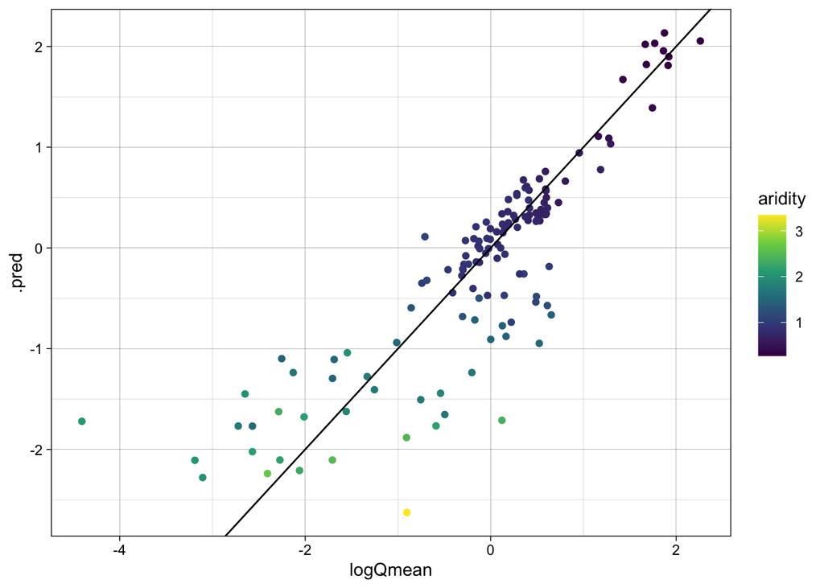

```r
ggplot(lm_data, aes(x = logQmean, y = .pred, colour = aridity)) +
  scale_color_viridis_c() +
  geom_point() +
  geom_abline() +
  theme_linedraw()
```

#switching it up

```r
#load baguette
rf_model <- rand_forest() %>%
  set_engine("ranger", importance = "impurity") %>%
  set_mode("regression")

rf_wf <- workflow() %>%
  # Add the recipe
  add_recipe(rec) %>%
  # Add the model
  add_model(rf_model) %>%
  # Fit the model
  fit(data = camels_train)
```

```r
rf_data <- augment(rf_wf, new_data = camels_test)
dim(rf_data)
```

```
[1] 135  60
```

#statistical and visual model evaluations

```r
metrics(rf_data, truth = logQmean, estimate = .pred)
```

```
# A tibble: 3 × 3
  .metric .estimator .estimate
  <chr>   <chr>          <dbl>
1 rmse    standard       0.587
2 rsq     standard       0.741
3 mae     standard       0.363
```

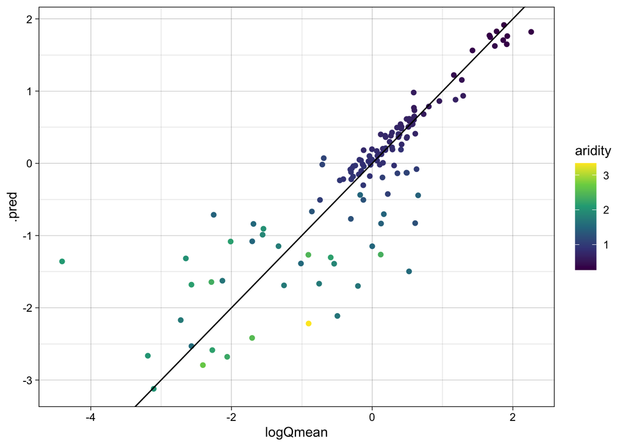

```r
ggplot(rf_data, aes(x = logQmean, y = .pred, colour = aridity)) +
  scale_color_viridis_c() +
  geom_point() +
  geom_abline() +
  theme_linedraw()
```

#the workflowset approach

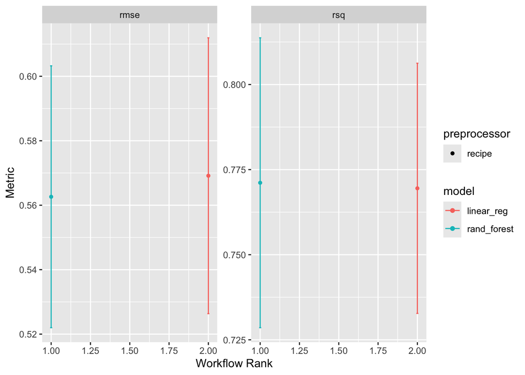

```r
wf <- workflow_set(list(rec), list(lm_model, rf_model)) %>%
  workflow_map('fit_resamples', resamples = camels_cv)

autoplot(wf)
```

```r
rank_results(wf, rank_metric = "rsq", select_best = TRUE)
```

```
# A tibble: 4 × 9
  wflow_id          .config .metric  mean std_err     n preprocessor model  rank
  <chr>             <chr>   <chr>   <dbl>   <dbl> <int> <chr>        <chr> <int>
1 recipe_rand_fore… Prepro… rmse    0.563  0.0247    10 recipe       rand…     1
2 recipe_rand_fore… Prepro… rsq     0.771  0.0259    10 recipe       rand…     1
3 recipe_linear_reg Prepro… rmse    0.569  0.0260    10 recipe       line…     2
4 recipe_linear_reg Prepro… rsq     0.770  0.0223    10 recipe       line…     2
```

## Question Three

```r
library(xgboost)
```

```r
xgb_model <- boost_tree(trees = 1000,
                        tree_depth = 6,
                        learn_rate = 0.01) %>%
  set_engine("xgboost") %>%
  set_mode("regression")

xgb_workflow <- workflow() %>%
  add_recipe(rec) %>%
  add_model(xgb_model) %>%
  fit(data = camels_train)
```

#Neutral network model

```r
nn_model <- bag_mlp() %>%
  set_engine("nnet", times = 10) %>%
  set_mode("regression")

nn_workflow <- workflow() %>%
  add_recipe(rec) %>%
  add_model(nn_model) %>%
  fit(data = camels_train)
```

#evaluate

```r
xgb_data <- augment(xgb_workflow, new_data = camels_test)
nn_data <- augment(nn_workflow, new_data = camels_test)

metrics(xgb_data, truth = logQmean, estimate = .pred)
```

```
# A tibble: 3 × 3
  .metric .estimator .estimate
  <chr>   <chr>          <dbl>
1 rmse    standard       0.679
2 rsq     standard       0.667
3 mae     standard       0.413
```

```r
metrics(nn_data, truth = logQmean, estimate = .pred)
```

```
# A tibble: 3 × 3
  .metric .estimator .estimate
  <chr>   <chr>          <dbl>
1 rmse    standard       0.552
2 rsq     standard       0.768
3 mae     standard       0.343
```

#compare

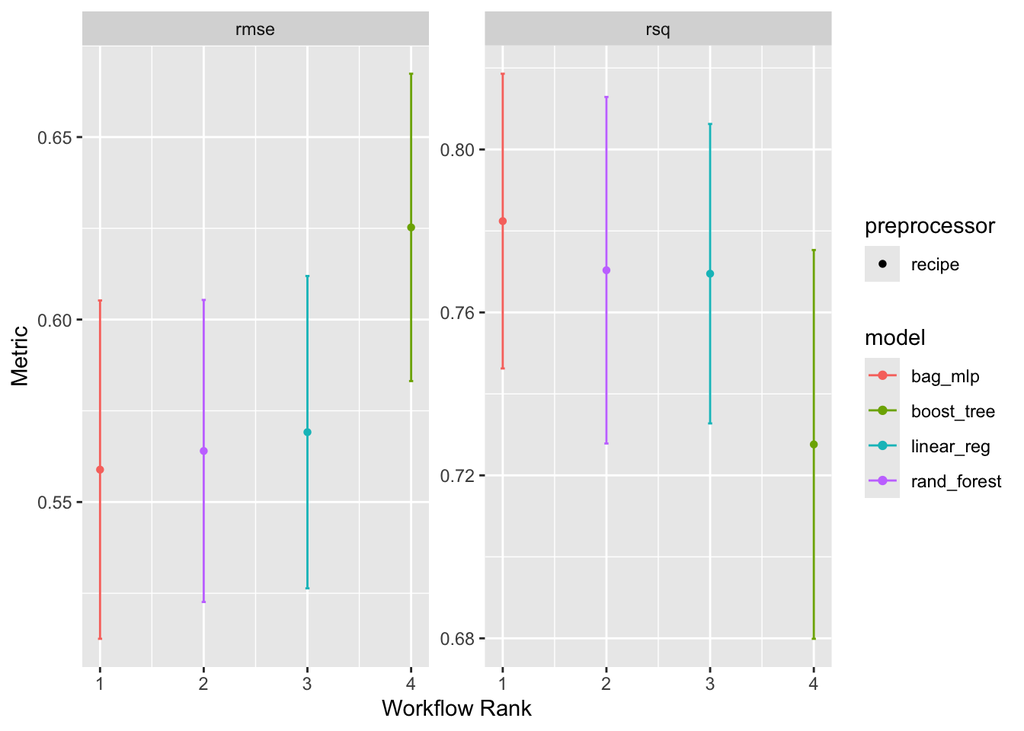

```r
wf <- workflow_set(
  list(rec),
  list(lm_model, rf_model, xgb_model, nn_model)) %>%
  workflow_map("fit_resamples", resamples = camels_cv)

autoplot(wf)
```

```r
rank_results(wf, rank_metric = "rsq", select_best = TRUE)
```

```
# A tibble: 8 × 9
  wflow_id          .config .metric  mean std_err     n preprocessor model  rank
  <chr>             <chr>   <chr>   <dbl>   <dbl> <int> <chr>        <chr> <int>
1 recipe_bag_mlp    Prepro… rmse    0.559  0.0282    10 recipe       bag_…     1
2 recipe_bag_mlp    Prepro… rsq     0.782  0.0220    10 recipe       bag_…     1
3 recipe_rand_fore… Prepro… rmse    0.564  0.0252    10 recipe       rand…     2
4 recipe_rand_fore… Prepro… rsq     0.770  0.0259    10 recipe       rand…     2
5 recipe_linear_reg Prepro… rmse    0.569  0.0260    10 recipe       line…     3
6 recipe_linear_reg Prepro… rsq     0.770  0.0223    10 recipe       line…     3
7 recipe_boost_tree Prepro… rmse    0.625  0.0256    10 recipe       boos…     4
8 recipe_boost_tree Prepro… rsq     0.728  0.0290    10 recipe       boos…     4
```

# the bag_mlp is the model that I would move forward with because it seems to outrank the other 3 models, even over rand_forest.

##Build Your Own

```r
set.seed(6245)
camels_split2 <- initial_split(camels, prop = 0.75)
camels_train2 <- training(camels_split2)
camels_test2 <- testing(camels_split2)
camels_cv2 <- vfold_cv(camels_train2, v = 10)

#Recipe
recipe2 <- recipe(logQmean ~ aridity + p_mean + elev_mean, data = camels_train) %>%
  step_log(all_predictors()) %>%
  step_interact(terms = ~ aridity:p_mean) %>%
  step_naomit(all_predictors(), all_outcomes())
```

#defining three different models

```r
rf_model2 <- rand_forest() %>%
  set_engine("ranger") %>%
  set_mode("regression")

xgb_model2 <- boost_tree(trees = 1000, tree_depth = 6, learn_rate = 0.01) %>%
  set_engine("xgboost") %>%
  set_mode("regression")

nn_model2 <- bag_mlp() %>%
  set_engine("nnet", times = 10) %>%
  set_mode("regression")
```

#workflow set

```r
wf2 <- workflow_set(
  preproc = list(rec),
  models = list(rf_model2, xgb_model2, nn_model2)) %>%
  workflow_map("fit_resamples", resamples = camels_cv2)
```

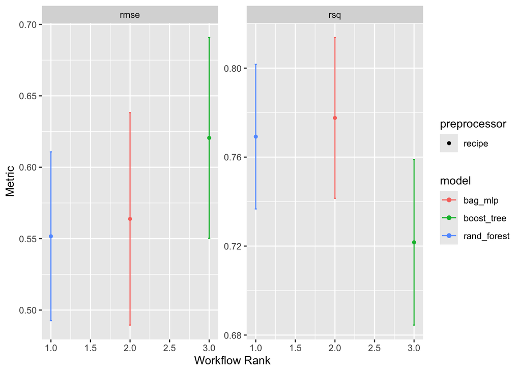

```r
autoplot(wf2)
```

```r
rank_results(wf2, rank_metric = "rsq", select_best = TRUE)
```

```
# A tibble: 6 × 9
  wflow_id          .config .metric  mean std_err     n preprocessor model  rank
  <chr>             <chr>   <chr>   <dbl>   <dbl> <int> <chr>        <chr> <int>
1 recipe_bag_mlp    Prepro… rmse    0.564  0.0452    10 recipe       bag_…     1
2 recipe_bag_mlp    Prepro… rsq     0.778  0.0220    10 recipe       bag_…     1
3 recipe_rand_fore… Prepro… rmse    0.552  0.0359    10 recipe       rand…     2
4 recipe_rand_fore… Prepro… rsq     0.769  0.0198    10 recipe       rand…     2
5 recipe_boost_tree Prepro… rmse    0.621  0.0427    10 recipe       boos…     3
6 recipe_boost_tree Prepro… rsq     0.722  0.0226    10 recipe       boos…     3
```

# The bag_mlp wins again! This is the best model fir this type of data because they combine all the previous trees into one final product, and because it works with the preporcessing transformations which work better than simple tree-based models.

```r
final_workflow <- workflow() %>%
  add_recipe(rec) %>%
  add_model(nn_model2) %>%
  fit(data = camels_train2)

final_data <- augment(final_workflow, new_data = camels_test2)

metrics(final_data, truth = logQmean, estimate = .pred)
```

```
# A tibble: 3 × 3
  .metric .estimator .estimate
  <chr>   <chr>          <dbl>
1 rmse    standard       1.04
2 rsq     standard       0.588
3 mae     standard       0.475
```

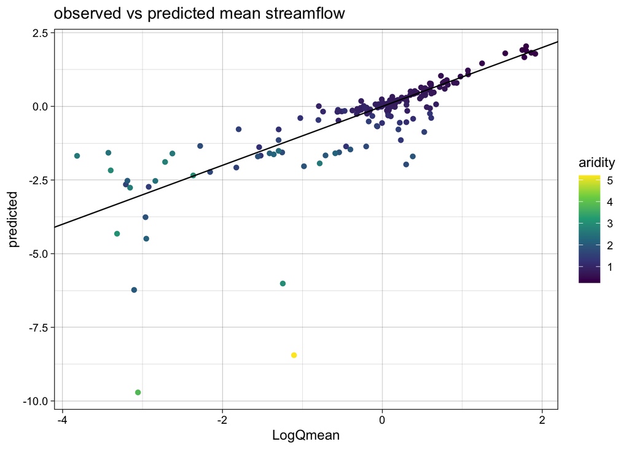

```r
ggplot(final_data, aes(x = logQmean, y = .pred, colour = aridity)) +
  scale_color_viridis_c() +
  geom_point() +
  geom_abline() +
  theme_linedraw() +
  labs(title = "observed vs predicted mean streamflow",
       x = "LogQmean",
       y = "predicted",
       color = "aridity")
```